# Snow Data Assignment: Web Scraping, Functions, and Iteration

Kaydee Barker

2/7/2022

# Assignment

## 1. Extract the meteorological data URLs. Here we want you to use the `rvest` package to get the URLs for the `SASP forcing` and `SBSP_forcing` meteorological datasets.

```
## [1] "https://snowstudies.org/wp-content/uploads/2022/02/SBB_SASP_Forcing_Data.txt"
## [2] "https://snowstudies.org/wp-content/uploads/2022/02/SBB_SBSP_Forcing_Data.txt"
```

## 2. Download the meteorological data. Use the `download_file` and `str_split_fixed` commands to download the data and save it in your data folder. You can use a for loop or a map function.

```
## [1] "SBB_SASP_Forcing_Data.txt" "SBB_SBSP_Forcing_Data.txt"
```

```
## [1] "data downloaded"
```

## 3. Write a custom function to read in the data and append a site column to the data.

## 4. Use the `map` function to read in both meteorological files. Display a summary of your tibble.

```
##       year          month             day             hour
##  Min.   :2003   Min.   : 1.000   Min.   : 1.00   Min.   : 0.00
##  1st Qu.:2005   1st Qu.: 3.000   1st Qu.: 8.00   1st Qu.: 5.75
##  Median :2007   Median : 6.000   Median :16.00   Median :11.50
##  Mean   :2007   Mean   : 6.472   Mean   :15.76   Mean   :11.50
##  3rd Qu.:2009   3rd Qu.: 9.000   3rd Qu.:23.00   3rd Qu.:17.25
##  Max.   :2011   Max.   :12.000   Max.   :31.00   Max.   :23.00
##      precip             air_temp         site
##  Min.   :0.000e+00   Min.   :242.1   Length:138336
##  1st Qu.:0.000e+00   1st Qu.:265.8   Class :character
##  Median :0.000e+00   Median :272.6   Mode  :character
##  Mean   :3.838e-05   Mean   :272.6
##  3rd Qu.:0.000e+00   3rd Qu.:279.7
##  Max.   :6.111e-03   Max.   :295.8
```

## 5. Make a line plot of mean temp by year by site (using the `air temp [K]` variable). Is there anything suspicious in the plot? Adjust your filtering if needed.

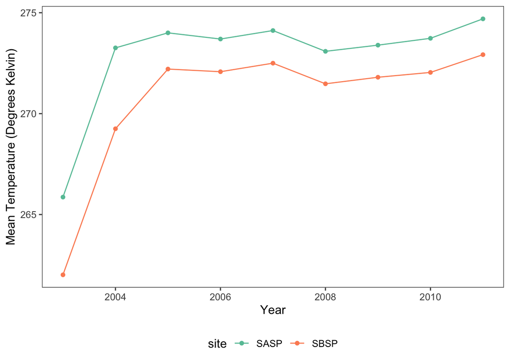

## 6. Write a function that makes line plots of monthly average temperature at each site for a given year. Use a for loop to make these plots for 2005 to 2010.

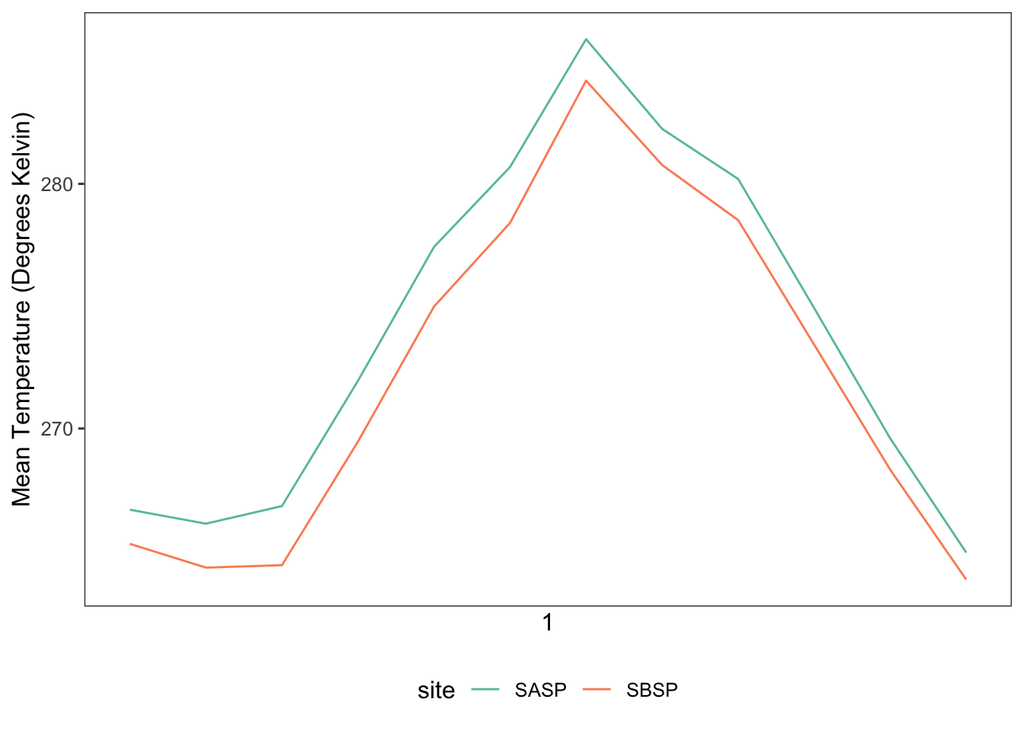

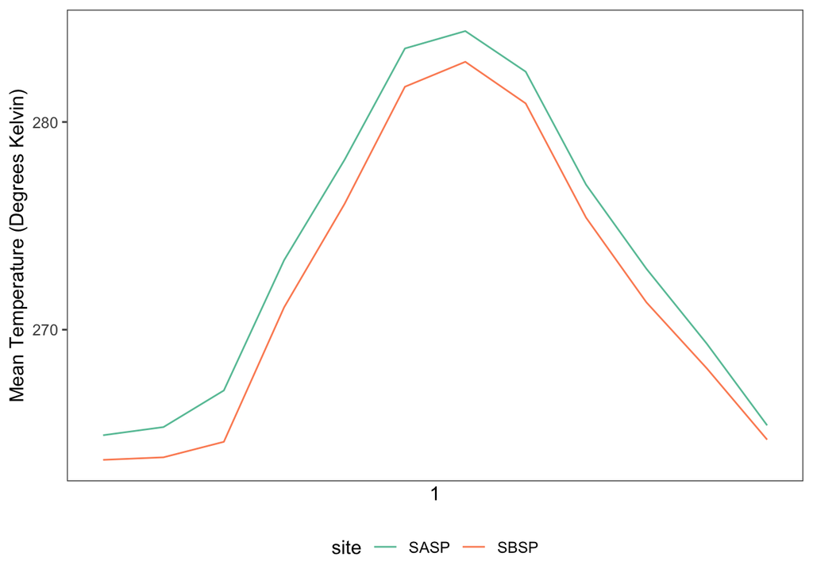

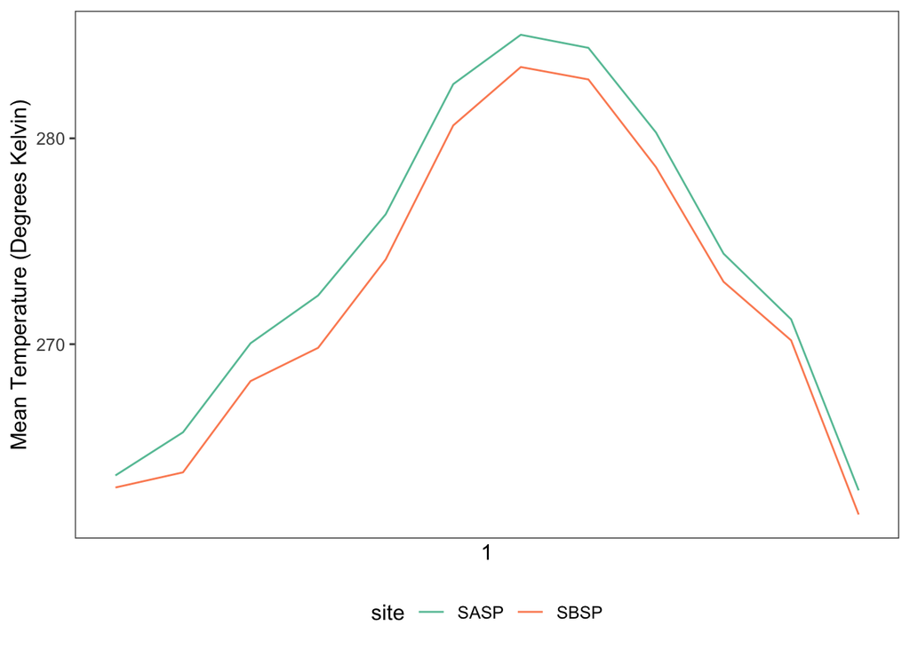

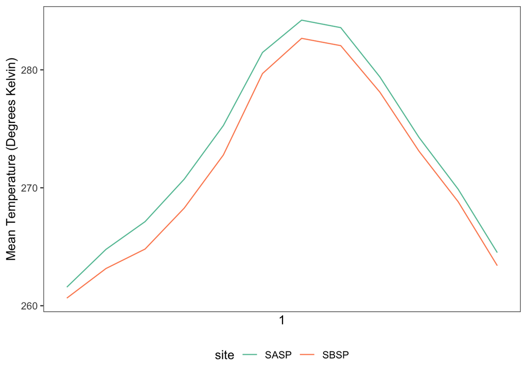

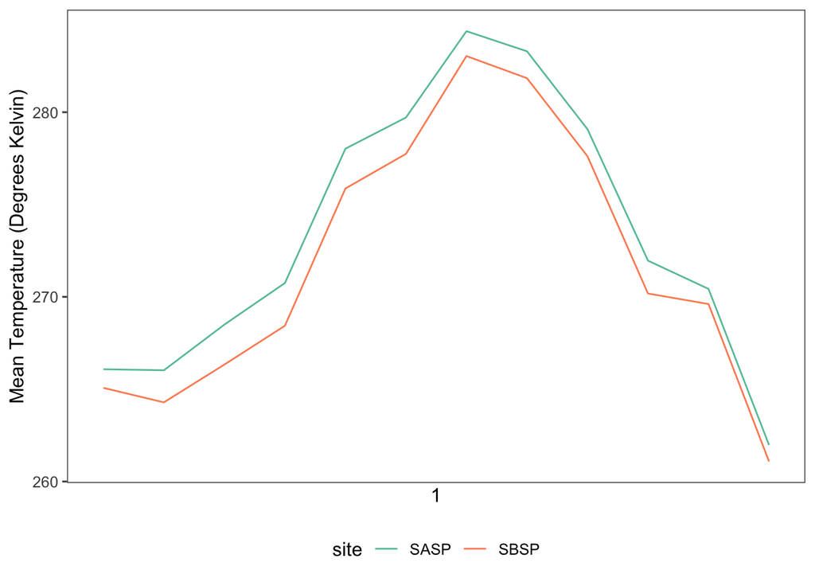

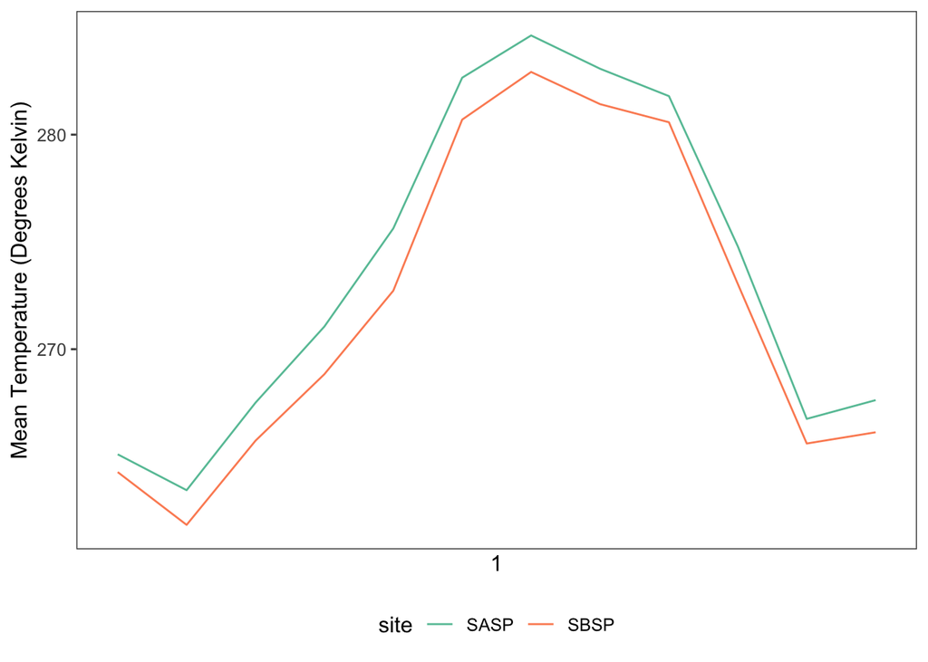